# Modeling Air Temperature of a Time Period

Hao-Ran Wu ( haoranwu @ zju.edu.cn )

2022-09-24

In this section we are concerned about how to calculate diel air temperature of a time period through the function `hourlyT()`.

## Code Example

```r
# Calculate 2016 Diel Air Temperature of Kellogg Biological Station
# *****************************************************************
#
# Calculate diel air temperature based on the algorithm proposed by Parton and
# Logan (1981). Data used in this example is collected in 2016 from Kellogg
# Biological Station (KBS), Michigan, USA (Zenone et al., 2011, 2013; Abraha et al.
# , 2015, 2018).
#
# ********************************
# List of variables and units for this example
#
# 'path'        path of a CSV file, which conains three columns (with table titles)
#                * column 1: observation date. Required format "dd/mm/yyyy"
#                * column 2: daily maximum temperature (Celsius or Fahrenheit)
#                * column 3: daily minimum temperature (Celsius or Fahrenheit)
# 'hours'       hours of the day
# 'lng'         longitute of the study site (decimal)
# 'lat'         latitude of the study site (decimal)
#
# ********************************
# Step 1: import package
require(bproce)

# Step 2: choose parameters
path  <- "./data/1-1B Switchgrass Time Series.csv"
hours <- seq(0, 23.5, 0.5)           # 0.5h, 1h, 1.5h, ..., 23.5h
lng   <- -85.446758
lat   <- 42.476708

# Step 3: read data
dat   <- read.csv(path)              # read the CSV file
                                     #  * column 1 ($date): observation date
                                     #  * column 2 ($t_max): maximum temperature
                                     #  * column 3 ($t_min): minimum temperature
day   <- as.numeric(lapply(strsplit(dat$date,"/"),function(xx) xx[1]))
                                     # extract day numbers from characters
month <- as.numeric(lapply(strsplit(dat$date,"/"),function(xx) xx[2]))
                                     # extract month numbers from characters
year  <- as.numeric(lapply(strsplit(dat$date,"/"),function(xx) xx[3]))
                                     # extract year numbers from characters
t_max <- dat$t_max                   # extract maximum temperatures
t_min <- dat$t_min                   # extract minimum temperatures

# Step 4: run the model
doys <- DOY(year, month, day)        # calculate day of the year (DOY)

time_sr <- as.numeric(lapply(lapply(doys, sunRS, lng, lat), function(xx) xx[1]))
                                      # calculate sunrise time
time_ss <- as.numeric(lapply(lapply(doys, sunRS, lng, lat), function(xx) xx[2]))
                                      # calculate sunset time

res <- do.call(rbind,lapply(1:nrow(dat), function(i){
    t_a <- hourlyT(hours, t_max[i], t_min[i], time_sr[i], time_ss[i],
                    alpha = 1.5, beta = 4, gamma = 1)
    data.frame(
      date    = rep(paste0(day[i],"/",month[i],"/",year[i]), length(hours)),
      time_sr = rep(time_sr[i], length(hours)),
      time_ss = rep(time_ss[i], length(hours)),
      hours   = hours,
      t_a     = t_a
    )
}))                                   # compute hourly air temperature

# Step 4: show and visualize results
# show first parts of the results
print(head(res))

# plot air temperature versus time
plot(
  x = (1:length(res$t_a))/length(hours),
  y = res$t_a,
  type = "l",
  xlab = "Day of the year",
  ylab = "Predicted air temperature",
  main = "2016 Annual Temperatures of Kellogg Biological Station"
)
```

## Explanation

**Step1:** Load the package `bproce` through the `require()` function.

```r
require(bproce)
```

**Step2:** Choose model parameters.

```r
path  <- "./data/1-1B Switchgrass Time Series.csv"
hours <- seq(0, 23.5, 0.5)
lng   <- -85.446758
lat   <- 42.476708
```

**Step3:** Read data. Read the CSV file in table format and creates a data frame through the function `read.csv()`.

```r
dat <- read.csv(path)
head(dat)  #print first parts of the data
```

```
        date   t_max    t_min
1 01/01/2016 -2.1622  -4.1469
2 02/01/2016  3.1132  -2.1903
3 03/01/2016  1.8934  -2.8907
4 04/01/2016 -1.4289 -11.6573
5 05/01/2016  0.0201 -13.3976
6 06/01/2016  5.1338  -8.5460
```

Then the day, month, and year are extracted from date list through the function `strsplit()`.

```r
day   <- as.numeric(lapply(strsplit(dat$date,"/"),function(xx) xx[1]))
                                     # extract day numbers from characters
month <- as.numeric(lapply(strsplit(dat$date,"/"),function(xx) xx[2]))
                                     # extract month numbers from characters
year  <- as.numeric(lapply(strsplit(dat$date,"/"),function(xx) xx[3]))
                                     # extract year numbers from characters

cat(
  "Dates:",head(dat$date),"...\n",
  "************Extract day, month, and year numbers************\n",
  "Days:",head(day),"...\n",
  "Months:",head(month),"...\n",
  "Years:",head(year),"...\n"
)
```

```
Dates: 01/01/2016 02/01/2016 03/01/2016 04/01/2016 05/01/2016 06/01/2016 ...
 ************Extract day, month, and year numbers************
 Days: 1 2 3 4 5 6 ...
 Months: 1 1 1 1 1 1 ...
 Years: 2016 2016 2016 2016 2016 2016 ...
```

Daily maximum and minimum temperatures can also be extracted from `dat`.

```r
t_max <- dat$t_max                   # extract maximum temperatures
t_min <- dat$t_min                   # extract minimum temperatures

cat(
  "Dates:",head(dat$date),"...\n",
  "T_{max}:",round(head(t_max),2),"...\n",
  "T_{min}:",round(head(t_min),2),"...\n"
)
```

```
Dates: 01/01/2016 02/01/2016 03/01/2016 04/01/2016 05/01/2016 06/01/2016 ...
 T_{max}: -2.16 3.11 1.89 -1.43 0.02 5.13 ...
 T_{min}: -4.15 -2.19 -2.89 -11.66 -13.4 -8.55 ...
```

**Step4:** Run the model. The first step is to calculate day of the year (DOY) using the following equation:

$$\text{DOY}=\left[ \frac{275\text{month}}{9}
\right]-\left[\frac{\text{month}+9}{12}\right]·
\left(\left[ \frac{\text{year}-4\text[\text{year}/4]+2}{3}
\right]+1\right)+\text{day}-30,\quad(1)$$

```r
doys <- DOY(year, month, day)

cat(
  "Dates:", head(dat$date),"...\n",
  "DOYs:", head(doys),"...\n"
)
```

```
Dates: 01/01/2016 02/01/2016 03/01/2016 04/01/2016 05/01/2016 06/01/2016 ...
 DOYs: 1 2 3 4 5 6 ...
```

Sunrise time (Time<sub>sr</sub>, hour) and sunset time (Time<sub>ss</sub>, hour) are then calculated through the function `sunRS()` (see Section 1.4 for theoretical formulations):

```r
time_sr <- as.numeric(lapply(lapply(doys, sunRS, lng, lat), function(xx) xx[1]))
                                      # calculate sunrise time
time_ss <- as.numeric(lapply(lapply(doys, sunRS, lng, lat), function(xx) xx[2]))
                                      # calculate sunset time

cat(
  paste0("Longitude = ",lng, ", Latitude = ",lat,"\n"),
  "Date:", head(dat$date),"...\n",
  "Sunrise Time:", round(head(time_sr),3),"... (hour)\n",
  "Sunset Time:", round(head(time_ss),3),"... (hour)\n"
)
```

```
Longitude = -85.446758, Latitude = 42.476708
 Date: 01/01/2016 02/01/2016 03/01/2016 04/01/2016 05/01/2016 06/01/2016 ...
 Sunrise Time: 7.496 7.498 7.498 7.498 7.497 7.496 ... (hour)
 Sunset Time: 16.63 16.645 16.66 16.675 16.691 16.708 ... (hour)
```

A model proposed by Parton and Logan (1981) is then used to calculate air temperature. Air temperature $T_a$ between sunrise (plus an time lag $\gamma$ for $T_{min}$) and sunset is calculated as:

$$T_a=(T_{max}-T_{min})·\sin\left(
\frac{\pi·m}{D_L+2\alpha}\right)+T_{min},\quad(2)$$
where *m* is the number of hours after $T_{min}$ occurs, $D_L$ is the day length (hour), and $\alpha$ is the lag coefficient for $T_{max}$. The day length can be calculated from geographic positions and DOY (see Section 1.4). For nighttime air temperature, the following function is used:

$$T_a=T_{min}+(T_{sr}-T_{min})·e^{-\beta·\frac
nZ},\quad(3)$$
where $T_{sr}$ is the temperature at sunrise, $\beta$ is the nighttime temperature coefficient, $n$ is the number of hours after the sunset, and $Z$ is the night length (hour). $T_{sr}$ can be calculated as:

$$T_{sr}=(T_{max}-T_{min})·\sin\left(
\frac{\pi·(D_L-\gamma)}{D_L+2\alpha}\right)+T_{min},\quad(4)$$

where $\gamma$ is the time lag for $T_{min}$. All these work can be done after the function `hourlyT()` is called:

```r
res <- do.call(rbind, lapply(1:nrow(dat), function(i){
    t_a <- hourlyT(hours, t_max[i], t_min[i], time_sr[i], time_ss[i],
                    alpha = 1.5, beta = 4, gamma = 1)
    data.frame(
      date    = rep(paste0(day[i],"/",month[i],"/",year[i]), length(hours)),
      time_sr = rep(time_sr[i], length(hours)),
      time_ss = rep(time_ss[i], length(hours)),
      hours   = hours,
      t_a     = t_a
    )
}))

print(head(res), digits = 3)
```

```
      date time_sr time_ss hours   t_a
1 1/1/2016     7.5    16.6   0.0 -3.91
2 1/1/2016     7.5    16.6   0.5 -3.94
3 1/1/2016     7.5    16.6   1.0 -3.97
4 1/1/2016     7.5    16.6   1.5 -3.99
5 1/1/2016     7.5    16.6   2.0 -4.01
6 1/1/2016     7.5    16.6   2.5 -4.03
```

```r
    # 'res': an object of data frame type
    # each row shows the predicted air temperature at a single time point
    # for example, the third row shows that the predict air temperature at
    #     1:00 a.m. on 01/01/2016 is -3.97 Celsuis
    #   * Column 1: observation date
    #   * Column 2: sunrise time
    #   * Column 3: sunset time
    #   * Column 4: hours of the day
    #   * Column 5: predicted air temperature
```

The arguments and their meaning of `hourlyT()` is shown in the table below:

| Argument | Data Type | Meaning | Symbol |
| --- | --- | --- | --- |
| `hours` | vector | time in hours used for calculating air temperature | / |
| `t_max` | scalar | maximum air temperature (Celsius or Fahrenheit) | $T_{max}$ |
| `t_min` | scalar | minimum air temperature (Celsius or Fahrenheit) | $T_{min}$ |
| `time_sr` | scalar | sunrise time (hour) | $\text{Time}_{\text{sr}}$ |
| `time_ss` | scalar | sunset time (hour) | $\text{Time}_{\text{ss}}$ |
| `alpha` | scalar | lag time for $T_{max}$ (hour). Default 1.5. | $\alpha$ |
| `beta` | scalar | nighttime temperature coefficient. Default 4. | $\beta$ |
| `gamma` | scalar | lag time for $T_{min}$ (hour). Default 1. | $\gamma$ |

**Step5:** Save and visualize results. Use the `write.csv()` function to send outputs to a CSV file.

```r
write.csv(res,
          "./data/1-1B Switchgrass Diel Air Temperature Output.csv",
          row.names = FALSE)
```

Create a line plot of predicted air temperature against time through the function `plot()`:

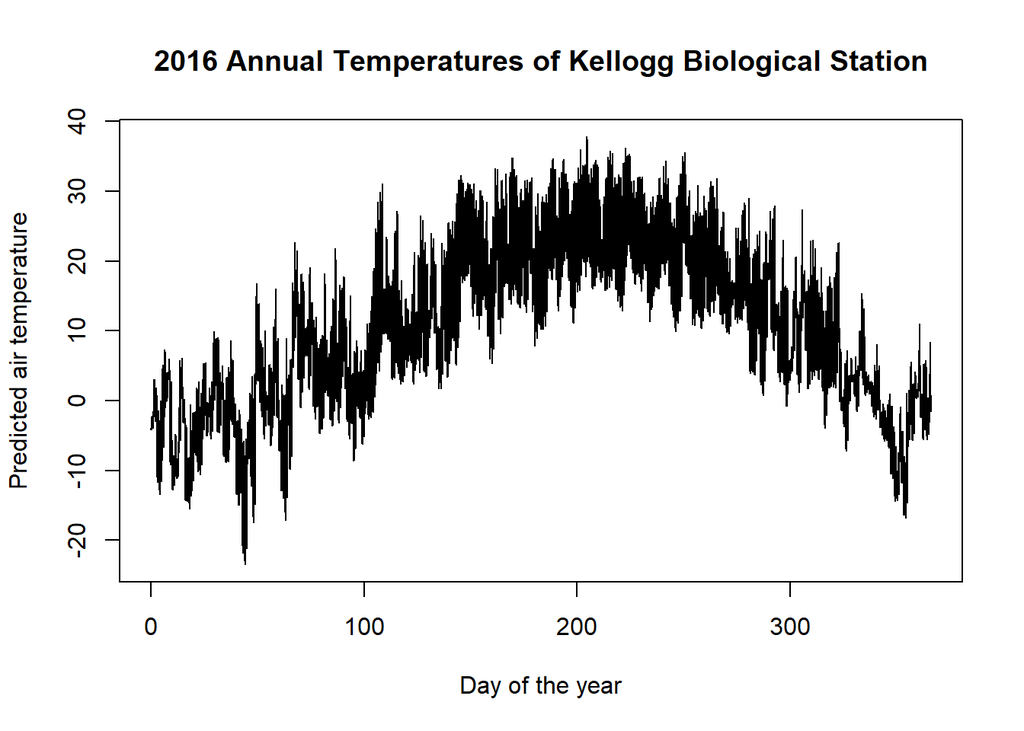

```r
plot(
  x = (1:length(res$t_a))/length(hours),
  y = res$t_a,
  type = "l",
  xlab = "Day of the year",
  ylab = "Predicted air temperature",
  main = "2016 Annual Temperatures of Kellogg Biological Station"
)
```

## References

Abraha, M., Chen, J., Chu, H., Zenone, T., John, R., Su, Y. J., Hamilton, S. K., and Robertson, G. P. (2015). Evapotranspiration of annual and perennial biofuel crops in a variable climate. Global Change Biology-Bioenergy, 7(6), 1344–1356.

Abraha, M., Hamilton, S. K., Chen, J., and Robertson, G. P. (2018). Ecosystemcarbon exchange on conversion of Conservation Reserve Program grasslands to annual and perennial cropping systems. Agricultural and Forest Meteorology, 253, 151–160.

Parton, W. J., and Logan, J. A. (1981). A model for diurnal variation in soil and air temperature. Agricultural Meteorology, 23, 205–216.

Zenone, T., Chen, J., Deal, M. W., Wilske, B., Jasrotia, P., Xu, J., Bhardwaj, A. K., Hamilton, S. K., and Robertson, G. P. (2011). CO<sub>2</sub> fluxes of transitional bioenergy crops: Effect of land conversion during the first year of cultivation. Global Change Biology-Bioenergy, 3(5), 401–412.

Zenone, T., Gelfand, I., Chen, J., Hamilton, S. K., and Robertson, G. P. (2013). From set-aside grassland to annual and perennial cellulosic biofuel crops: Effects of land use change on carbon balance. Agricultural and Forest Meteorology, 182, 1–12.